# Risk Factor Analysis

## Outcome Variable

**Outcome Variable:** wasted

## Predictor Variables

**Intervention Variable:** birthwt

**Adjustment Set:**

- arm
- sex
- W_mage
- meducyrs
- feducyrs
- vagbrth
- single
- brthmon
- W_parity
- delta_W_mage
- delta_meducyrs
- delta_feducyrs
- delta_vagbrth
- delta_single
- delta_brthmon
- delta_W_parity

## Stratifying Variables

The analysis was stratified on these variable(s):

- agecat
- studyid
- country

## Data Summary

| agecat | studyid | country | birthwt | wasted | n_cell | n |
| --- | --- | --- | --- | --- | --- | --- |
| Birth | ki0047075b-MAL-ED | BANGLADESH | Normal or high birthweight | 0 | 157 | 215 |
| Birth | ki0047075b-MAL-ED | BANGLADESH | Normal or high birthweight | 1 | 20 | 215 |
| Birth | ki0047075b-MAL-ED | BANGLADESH | Low birthweight | 0 | 22 | 215 |
| Birth | ki0047075b-MAL-ED | BANGLADESH | Low birthweight | 1 | 16 | 215 |
| Birth | ki0047075b-MAL-ED | BRAZIL | Normal or high birthweight | 0 | 59 | 62 |
| Birth | ki0047075b-MAL-ED | BRAZIL | Normal or high birthweight | 1 | 1 | 62 |
| Birth | ki0047075b-MAL-ED | BRAZIL | Low birthweight | 0 | 1 | 62 |
| Birth | ki0047075b-MAL-ED | BRAZIL | Low birthweight | 1 | 1 | 62 |
| Birth | ki0047075b-MAL-ED | INDIA | Normal or high birthweight | 0 | 36 | 45 |
| Birth | ki0047075b-MAL-ED | INDIA | Normal or high birthweight | 1 | 2 | 45 |
| Birth | ki0047075b-MAL-ED | INDIA | Low birthweight | 0 | 4 | 45 |
| Birth | ki0047075b-MAL-ED | INDIA | Low birthweight | 1 | 3 | 45 |
| Birth | ki0047075b-MAL-ED | NEPAL | Normal or high birthweight | 0 | 24 | 26 |
| Birth | ki0047075b-MAL-ED | NEPAL | Normal or high birthweight | 1 | 0 | 26 |
| Birth | ki0047075b-MAL-ED | NEPAL | Low birthweight | 0 | 0 | 26 |
| Birth | ki0047075b-MAL-ED | NEPAL | Low birthweight | 1 | 2 | 26 |
| Birth | ki0047075b-MAL-ED | PERU | Normal or high birthweight | 0 | 213 | 228 |
| Birth | ki0047075b-MAL-ED | PERU | Normal or high birthweight | 1 | 5 | 228 |
| Birth | ki0047075b-MAL-ED | PERU | Low birthweight | 0 | 10 | 228 |
| Birth | ki0047075b-MAL-ED | PERU | Low birthweight | 1 | 0 | 228 |
| Birth | ki0047075b-MAL-ED | SOUTH AFRICA | Normal or high birthweight | 0 | 104 | 120 |
| Birth | ki0047075b-MAL-ED | SOUTH AFRICA | Normal or high birthweight | 1 | 11 | 120 |
| Birth | ki0047075b-MAL-ED | SOUTH AFRICA | Low birthweight | 0 | 4 | 120 |
| Birth | ki0047075b-MAL-ED | SOUTH AFRICA | Low birthweight | 1 | 1 | 120 |
| Birth | ki0047075b-MAL-ED | TANZANIA, UNITED REPUBLIC OF | Normal or high birthweight | 0 | 113 | 115 |
| Birth | ki0047075b-MAL-ED | TANZANIA, UNITED REPUBLIC OF | Normal or high birthweight | 1 | 0 | 115 |
| Birth | ki0047075b-MAL-ED | TANZANIA, UNITED REPUBLIC OF | Low birthweight | 0 | 1 | 115 |
| Birth | ki0047075b-MAL-ED | TANZANIA, UNITED REPUBLIC OF | Low birthweight | 1 | 1 | 115 |
| Birth | ki1000108-CMC-V-BCS-2002 | INDIA | Normal or high birthweight | 0 | 71 | 86 |
| Birth | ki1000108-CMC-V-BCS-2002 | INDIA | Normal or high birthweight | 1 | 5 | 86 |

[output cut: 282 more lines]

The following strata were considered:

- agecat: 24 months, studyid: ki0047075b-MAL-ED, country: BANGLADESH
- agecat: 24 months, studyid: ki0047075b-MAL-ED, country: BRAZIL
- agecat: 24 months, studyid: ki0047075b-MAL-ED, country: INDIA
- agecat: 24 months, studyid: ki0047075b-MAL-ED, country: NEPAL
- agecat: 24 months, studyid: ki0047075b-MAL-ED, country: PERU
- agecat: 24 months, studyid: ki0047075b-MAL-ED, country: SOUTH AFRICA
- agecat: 24 months, studyid: ki0047075b-MAL-ED, country: TANZANIA, UNITED REPUBLIC OF
- agecat: 24 months, studyid: ki1000108-CMC-V-BCS-2002, country: INDIA
- agecat: 24 months, studyid: ki1000108-IRC, country: INDIA
- agecat: 24 months, studyid: ki1000109-EE, country: PAKISTAN
- agecat: 24 months, studyid: ki1017093-NIH-Birth, country: BANGLADESH
- agecat: 24 months, studyid: ki1017093b-PROVIDE, country: BANGLADESH
- agecat: 24 months, studyid: ki1017093c-NIH-Crypto, country: BANGLADESH
- agecat: 24 months, studyid: ki1066203-TanzaniaChild2, country: TANZANIA, UNITED REPUBLIC OF
- agecat: 24 months, studyid: ki1101329-Keneba, country: GAMBIA
- agecat: 24 months, studyid: ki1113344-GMS-Nepal, country: NEPAL
- agecat: 24 months, studyid: ki1114097-CMIN, country: BANGLADESH
- agecat: 24 months, studyid: ki1114097-CONTENT, country: PERU
- agecat: 24 months, studyid: ki1119695-PROBIT, country: BELARUS
- agecat: 24 months, studyid: ki1126311-ZVITAMBO, country: ZIMBABWE
- agecat: 24 months, studyid: ki1135781-COHORTS, country: GUATEMALA
- agecat: 24 months, studyid: ki1135781-COHORTS, country: INDIA
- agecat: 24 months, studyid: ki1135781-COHORTS, country: PHILIPPINES
- agecat: 24 months, studyid: kiGH5241-JiVitA-3, country: BANGLADESH
- agecat: 24 months, studyid: kiGH5241-JiVitA-4, country: BANGLADESH
- agecat: 6 months, studyid: ki0047075b-MAL-ED, country: BANGLADESH
- agecat: 6 months, studyid: ki0047075b-MAL-ED, country: BRAZIL
- agecat: 6 months, studyid: ki0047075b-MAL-ED, country: INDIA
- agecat: 6 months, studyid: ki0047075b-MAL-ED, country: NEPAL
- agecat: 6 months, studyid: ki0047075b-MAL-ED, country: PERU
- agecat: 6 months, studyid: ki0047075b-MAL-ED, country: SOUTH AFRICA
- agecat: 6 months, studyid: ki0047075b-MAL-ED, country: TANZANIA, UNITED REPUBLIC OF
- agecat: 6 months, studyid: ki1000108-CMC-V-BCS-2002, country: INDIA
- agecat: 6 months, studyid: ki1000108-IRC, country: INDIA
- agecat: 6 months, studyid: ki1000109-EE, country: PAKISTAN
- agecat: 6 months, studyid: ki1000109-ResPak, country: PAKISTAN
- agecat: 6 months, studyid: ki1000304b-SAS-CompFeed, country: INDIA
- agecat: 6 months, studyid: ki1017093-NIH-Birth, country: BANGLADESH
- agecat: 6 months, studyid: ki1017093b-PROVIDE, country: BANGLADESH
- agecat: 6 months, studyid: ki1017093c-NIH-Crypto, country: BANGLADESH
- agecat: 6 months, studyid: ki1066203-TanzaniaChild2, country: TANZANIA, UNITED REPUBLIC OF
- agecat: 6 months, studyid: ki1101329-Keneba, country: GAMBIA
- agecat: 6 months, studyid: ki1113344-GMS-Nepal, country: NEPAL
- agecat: 6 months, studyid: ki1114097-CMIN, country: BANGLADESH
- agecat: 6 months, studyid: ki1114097-CONTENT, country: PERU
- agecat: 6 months, studyid: ki1119695-PROBIT, country: BELARUS
- agecat: 6 months, studyid: ki1126311-ZVITAMBO, country: ZIMBABWE
- agecat: 6 months, studyid: ki1135781-COHORTS, country: GUATEMALA
- agecat: 6 months, studyid: ki1135781-COHORTS, country: INDIA
- agecat: 6 months, studyid: ki1135781-COHORTS, country: PHILIPPINES
- agecat: 6 months, studyid: kiGH5241-JiVitA-3, country: BANGLADESH
- agecat: 6 months, studyid: kiGH5241-JiVitA-4, country: BANGLADESH
- agecat: Birth, studyid: ki0047075b-MAL-ED, country: BANGLADESH
- agecat: Birth, studyid: ki0047075b-MAL-ED, country: BRAZIL
- agecat: Birth, studyid: ki0047075b-MAL-ED, country: INDIA
- agecat: Birth, studyid: ki0047075b-MAL-ED, country: NEPAL
- agecat: Birth, studyid: ki0047075b-MAL-ED, country: PERU
- agecat: Birth, studyid: ki0047075b-MAL-ED, country: SOUTH AFRICA
- agecat: Birth, studyid: ki0047075b-MAL-ED, country: TANZANIA, UNITED REPUBLIC OF
- agecat: Birth, studyid: ki1000108-CMC-V-BCS-2002, country: INDIA
- agecat: Birth, studyid: ki1000108-IRC, country: INDIA
- agecat: Birth, studyid: ki1000109-EE, country: PAKISTAN
- agecat: Birth, studyid: ki1000109-ResPak, country: PAKISTAN
- agecat: Birth, studyid: ki1000304b-SAS-CompFeed, country: INDIA
- agecat: Birth, studyid: ki1017093-NIH-Birth, country: BANGLADESH
- agecat: Birth, studyid: ki1017093b-PROVIDE, country: BANGLADESH
- agecat: Birth, studyid: ki1017093c-NIH-Crypto, country: BANGLADESH
- agecat: Birth, studyid: ki1101329-Keneba, country: GAMBIA
- agecat: Birth, studyid: ki1113344-GMS-Nepal, country: NEPAL
- agecat: Birth, studyid: ki1114097-CMIN, country: BANGLADESH
- agecat: Birth, studyid: ki1114097-CONTENT, country: PERU
- agecat: Birth, studyid: ki1119695-PROBIT, country: BELARUS
- agecat: Birth, studyid: ki1126311-ZVITAMBO, country: ZIMBABWE
- agecat: Birth, studyid: ki1135781-COHORTS, country: GUATEMALA
- agecat: Birth, studyid: ki1135781-COHORTS, country: INDIA
- agecat: Birth, studyid: ki1135781-COHORTS, country: PHILIPPINES
- agecat: Birth, studyid: kiGH5241-JiVitA-3, country: BANGLADESH
- agecat: Birth, studyid: kiGH5241-JiVitA-4, country: BANGLADESH

### Dropped Strata

Some strata were dropped due to rare outcomes:

- agecat: Birth, studyid: ki0047075b-MAL-ED, country: BRAZIL
- agecat: Birth, studyid: ki0047075b-MAL-ED, country: INDIA
- agecat: Birth, studyid: ki0047075b-MAL-ED, country: NEPAL
- agecat: Birth, studyid: ki0047075b-MAL-ED, country: PERU
- agecat: Birth, studyid: ki0047075b-MAL-ED, country: SOUTH AFRICA
- agecat: Birth, studyid: ki0047075b-MAL-ED, country: TANZANIA, UNITED REPUBLIC OF
- agecat: Birth, studyid: ki1000108-CMC-V-BCS-2002, country: INDIA
- agecat: Birth, studyid: ki1000109-ResPak, country: PAKISTAN
- agecat: Birth, studyid: ki1114097-CMIN, country: BANGLADESH
- agecat: Birth, studyid: ki1114097-CONTENT, country: PERU
- agecat: Birth, studyid: ki1119695-PROBIT, country: BELARUS
- agecat: 6 months, studyid: ki0047075b-MAL-ED, country: BANGLADESH
- agecat: 6 months, studyid: ki0047075b-MAL-ED, country: BRAZIL
- agecat: 6 months, studyid: ki0047075b-MAL-ED, country: INDIA
- agecat: 6 months, studyid: ki0047075b-MAL-ED, country: NEPAL
- agecat: 6 months, studyid: ki0047075b-MAL-ED, country: PERU
- agecat: 6 months, studyid: ki0047075b-MAL-ED, country: SOUTH AFRICA
- agecat: 6 months, studyid: ki0047075b-MAL-ED, country: TANZANIA, UNITED REPUBLIC OF
- agecat: 6 months, studyid: ki1000109-ResPak, country: PAKISTAN
- agecat: 6 months, studyid: ki1066203-TanzaniaChild2, country: TANZANIA, UNITED REPUBLIC OF
- agecat: 6 months, studyid: ki1114097-CMIN, country: BANGLADESH
- agecat: 6 months, studyid: ki1114097-CONTENT, country: PERU
- agecat: 6 months, studyid: ki1119695-PROBIT, country: BELARUS
- agecat: 6 months, studyid: ki1135781-COHORTS, country: GUATEMALA
- agecat: 24 months, studyid: ki0047075b-MAL-ED, country: BANGLADESH
- agecat: 24 months, studyid: ki0047075b-MAL-ED, country: BRAZIL
- agecat: 24 months, studyid: ki0047075b-MAL-ED, country: NEPAL
- agecat: 24 months, studyid: ki0047075b-MAL-ED, country: PERU
- agecat: 24 months, studyid: ki0047075b-MAL-ED, country: SOUTH AFRICA
- agecat: 24 months, studyid: ki0047075b-MAL-ED, country: TANZANIA, UNITED REPUBLIC OF
- agecat: 24 months, studyid: ki1066203-TanzaniaChild2, country: TANZANIA, UNITED REPUBLIC OF
- agecat: 24 months, studyid: ki1114097-CMIN, country: BANGLADESH
- agecat: 24 months, studyid: ki1114097-CONTENT, country: PERU
- agecat: 24 months, studyid: ki1119695-PROBIT, country: BELARUS

## Methods Detail

We’re interested in the causal parameters $E[Y_a]$ for all values of $a \in \mathcal{A}$. These parameters represent the mean outcome if, possibly contrary to fact, we intervened to set all units to have $A=a$. Under the randomization and positivity assumptions, these are identified by the statistical parameters $\psi_a=E_W[E_{Y|A,W}(Y|A=a,W)]$. In addition, we’re interested in the mean of $Y$, $E[Y]$ under no intervention (the observed mean). We will estimate these parameters by using SuperLearner to fit the relevant likelihood factors – $E_{Y|A,W}(Y|A=a,W)$ and $p(A=a|W)$, and then updating our likelihood fit using a joint TMLE.

For unadjusted analyses ($W=\{\}$), initial likelihoods were estimated using Lrnr_glm to estimate the simple $E(Y|A)$ and Lrnr_mean to estimate $p(A)$. For adjusted analyses, a small library containing Lrnr_glmnet, Lrnr_xgboost, and Lrnr_mean was used.

Having estimated these parameters, we will then use the delta method to estimate relative risks and attributable risks relative to a prespecified baseline level of $A$.

# Results Detail

## Results Plots

[figure not shown]

[figure not shown]

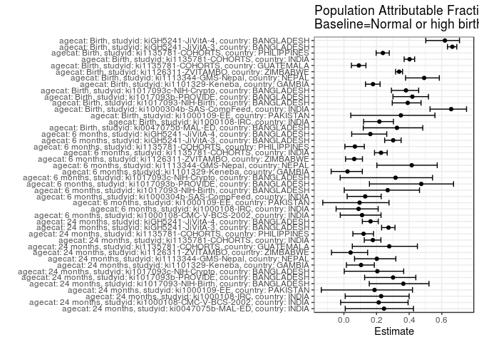

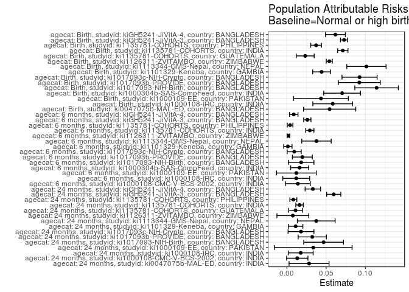

## Results Table

### Parameter: TSM

| agecat | studyid | country | intervention_level | baseline_level | estimate | ci_lower | ci_upper |
| --- | --- | --- | --- | --- | --- | --- | --- |
| Birth | ki0047075b-MAL-ED | BANGLADESH | Normal or high birthweight | NA | 0.1130020 | 0.0661974 | 0.1598066 |
| Birth | ki0047075b-MAL-ED | BANGLADESH | Low birthweight | NA | 0.4236431 | 0.2521374 | 0.5951487 |
| Birth | ki1000108-IRC | INDIA | Normal or high birthweight | NA | 0.2098644 | 0.1634157 | 0.2563131 |
| Birth | ki1000108-IRC | INDIA | Low birthweight | NA | 0.6445169 | 0.4995945 | 0.7894394 |
| Birth | ki1000109-EE | PAKISTAN | Normal or high birthweight | NA | 0.0808870 | 0.0352981 | 0.1264760 |
| Birth | ki1000109-EE | PAKISTAN | Low birthweight | NA | 0.2841597 | 0.1456423 | 0.4226771 |
| Birth | ki1000304b-SAS-CompFeed | INDIA | Normal or high birthweight | NA | 0.0366286 | 0.0208178 | 0.0524394 |
| Birth | ki1000304b-SAS-CompFeed | INDIA | Low birthweight | NA | 0.4017980 | 0.3308255 | 0.4727704 |
| Birth | ki1017093-NIH-Birth | BANGLADESH | Normal or high birthweight | NA | 0.1779295 | 0.1413798 | 0.2144791 |
| Birth | ki1017093-NIH-Birth | BANGLADESH | Low birthweight | NA | 0.5994447 | 0.5208911 | 0.6779982 |
| Birth | ki1017093b-PROVIDE | BANGLADESH | Normal or high birthweight | NA | 0.1276554 | 0.0947298 | 0.1605809 |
| Birth | ki1017093b-PROVIDE | BANGLADESH | Low birthweight | NA | 0.5142551 | 0.4246819 | 0.6038283 |
| Birth | ki1017093c-NIH-Crypto | BANGLADESH | Normal or high birthweight | NA | 0.1507298 | 0.1209785 | 0.1804811 |
| Birth | ki1017093c-NIH-Crypto | BANGLADESH | Low birthweight | NA | 0.5761182 | 0.4961872 | 0.6560492 |
| Birth | ki1101329-Keneba | GAMBIA | Normal or high birthweight | NA | 0.2035967 | 0.1814433 | 0.2257501 |
| Birth | ki1101329-Keneba | GAMBIA | Low birthweight | NA | 0.5433138 | 0.4716056 | 0.6150221 |
| Birth | ki1113344-GMS-Nepal | NEPAL | Normal or high birthweight | NA | 0.1046365 | 0.0770283 | 0.1322448 |
| Birth | ki1113344-GMS-Nepal | NEPAL | Low birthweight | NA | 0.4834305 | 0.4064377 | 0.5604232 |
| Birth | ki1126311-ZVITAMBO | ZIMBABWE | Normal or high birthweight | NA | 0.1055742 | 0.0999795 | 0.1111688 |
| Birth | ki1126311-ZVITAMBO | ZIMBABWE | Low birthweight | NA | 0.6382924 | 0.6114585 | 0.6651263 |
| Birth | ki1135781-COHORTS | GUATEMALA | Normal or high birthweight | NA | 0.2306855 | 0.1994909 | 0.2618800 |
| Birth | ki1135781-COHORTS | GUATEMALA | Low birthweight | NA | 0.5611051 | 0.4216201 | 0.7005901 |
| Birth | ki1135781-COHORTS | INDIA | Normal or high birthweight | NA | 0.1057762 | 0.0973941 | 0.1141583 |
| Birth | ki1135781-COHORTS | INDIA | Low birthweight | NA | 0.5404418 | 0.5096069 | 0.5712768 |
| Birth | ki1135781-COHORTS | PHILIPPINES | Normal or high birthweight | NA | 0.1184127 | 0.1061995 | 0.1306258 |
| Birth | ki1135781-COHORTS | PHILIPPINES | Low birthweight | NA | 0.6274293 | 0.5621958 | 0.6926628 |
| Birth | kiGH5241-JiVitA-3 | BANGLADESH | Normal or high birthweight | NA | 0.0367378 | 0.0331238 | 0.0403518 |
| Birth | kiGH5241-JiVitA-3 | BANGLADESH | Low birthweight | NA | 0.2758956 | 0.2627460 | 0.2890452 |
| Birth | kiGH5241-JiVitA-4 | BANGLADESH | Normal or high birthweight | NA | 0.0380016 | 0.0254290 | 0.0505742 |
| Birth | kiGH5241-JiVitA-4 | BANGLADESH | Low birthweight | NA | 0.2756069 | 0.2331744 | 0.3180393 |

[output cut: 58 more lines]

### Parameter: E(Y)

| agecat | studyid | country | intervention_level | baseline_level | estimate | ci_lower | ci_upper |
| --- | --- | --- | --- | --- | --- | --- | --- |
| Birth | ki0047075b-MAL-ED | BANGLADESH | NA | NA | 0.1674419 | 0.1174176 | 0.2174661 |
| Birth | ki1000108-IRC | INDIA | NA | NA | 0.2682216 | 0.2212677 | 0.3151755 |
| Birth | ki1000109-EE | PAKISTAN | NA | NA | 0.1242938 | 0.0755526 | 0.1730349 |
| Birth | ki1000304b-SAS-CompFeed | INDIA | NA | NA | 0.1069810 | 0.0760961 | 0.1378659 |
| Birth | ki1017093-NIH-Birth | BANGLADESH | NA | NA | 0.2921739 | 0.2549711 | 0.3293768 |
| Birth | ki1017093b-PROVIDE | BANGLADESH | NA | NA | 0.2199248 | 0.1846953 | 0.2551543 |
| Birth | ki1017093c-NIH-Crypto | BANGLADESH | NA | NA | 0.2432815 | 0.2116319 | 0.2749310 |
| Birth | ki1101329-Keneba | GAMBIA | NA | NA | 0.2477816 | 0.2256667 | 0.2698964 |
| Birth | ki1113344-GMS-Nepal | NEPAL | NA | NA | 0.2059282 | 0.1745993 | 0.2372572 |
| Birth | ki1126311-ZVITAMBO | ZIMBABWE | NA | NA | 0.1595572 | 0.1532418 | 0.1658725 |
| Birth | ki1135781-COHORTS | GUATEMALA | NA | NA | 0.2539683 | 0.2229196 | 0.2850169 |
| Birth | ki1135781-COHORTS | INDIA | NA | NA | 0.1769740 | 0.1674681 | 0.1864799 |
| Birth | ki1135781-COHORTS | PHILIPPINES | NA | NA | 0.1555709 | 0.1423748 | 0.1687670 |
| Birth | kiGH5241-JiVitA-3 | BANGLADESH | NA | NA | 0.1095259 | 0.1044047 | 0.1146471 |
| Birth | kiGH5241-JiVitA-4 | BANGLADESH | NA | NA | 0.0997496 | 0.0843744 | 0.1151247 |
| 6 months | ki1000108-CMC-V-BCS-2002 | INDIA | NA | NA | 0.1250000 | 0.0911644 | 0.1588356 |
| 6 months | ki1000108-IRC | INDIA | NA | NA | 0.1318408 | 0.0987276 | 0.1649539 |
| 6 months | ki1000109-EE | PAKISTAN | NA | NA | 0.1256684 | 0.0920293 | 0.1593076 |
| 6 months | ki1000304b-SAS-CompFeed | INDIA | NA | NA | 0.1238671 | 0.0990601 | 0.1486741 |
| 6 months | ki1017093-NIH-Birth | BANGLADESH | NA | NA | 0.0675676 | 0.0459314 | 0.0892038 |
| 6 months | ki1017093b-PROVIDE | BANGLADESH | NA | NA | 0.0414594 | 0.0255348 | 0.0573839 |
| 6 months | ki1017093c-NIH-Crypto | BANGLADESH | NA | NA | 0.0293706 | 0.0169860 | 0.0417552 |
| 6 months | ki1101329-Keneba | GAMBIA | NA | NA | 0.0554723 | 0.0431843 | 0.0677602 |
| 6 months | ki1113344-GMS-Nepal | NEPAL | NA | NA | 0.0905861 | 0.0668565 | 0.1143158 |
| 6 months | ki1126311-ZVITAMBO | ZIMBABWE | NA | NA | 0.0311578 | 0.0274581 | 0.0348575 |
| 6 months | ki1135781-COHORTS | INDIA | NA | NA | 0.1282790 | 0.1199892 | 0.1365687 |
| 6 months | ki1135781-COHORTS | PHILIPPINES | NA | NA | 0.0593093 | 0.0503382 | 0.0682804 |
| 6 months | kiGH5241-JiVitA-3 | BANGLADESH | NA | NA | 0.0859979 | 0.0808738 | 0.0911219 |
| 6 months | kiGH5241-JiVitA-4 | BANGLADESH | NA | NA | 0.0536465 | 0.0439582 | 0.0633347 |
| 24 months | ki0047075b-MAL-ED | INDIA | NA | NA | 0.1146789 | 0.0722843 | 0.1570735 |
| 24 months | ki1000108-CMC-V-BCS-2002 | INDIA | NA | NA | 0.0618280 | 0.0373207 | 0.0863352 |
| 24 months | ki1000108-IRC | INDIA | NA | NA | 0.0769231 | 0.0508746 | 0.1029716 |
| 24 months | ki1000109-EE | PAKISTAN | NA | NA | 0.1785714 | 0.1204842 | 0.2366587 |
| 24 months | ki1017093-NIH-Birth | BANGLADESH | NA | NA | 0.1283293 | 0.0960341 | 0.1606245 |
| 24 months | ki1017093b-PROVIDE | BANGLADESH | NA | NA | 0.1070812 | 0.0818727 | 0.1322897 |
| 24 months | ki1017093c-NIH-Crypto | BANGLADESH | NA | NA | 0.0875486 | 0.0630907 | 0.1120065 |
| 24 months | ki1101329-Keneba | GAMBIA | NA | NA | 0.1059603 | 0.0873965 | 0.1245240 |
| 24 months | ki1113344-GMS-Nepal | NEPAL | NA | NA | 0.1851852 | 0.1506144 | 0.2197560 |
| 24 months | ki1126311-ZVITAMBO | ZIMBABWE | NA | NA | 0.1832947 | 0.1467250 | 0.2198644 |
| 24 months | ki1135781-COHORTS | GUATEMALA | NA | NA | 0.0395738 | 0.0246551 | 0.0544926 |
| 24 months | ki1135781-COHORTS | INDIA | NA | NA | 0.0908525 | 0.0827390 | 0.0989661 |
| 24 months | ki1135781-COHORTS | PHILIPPINES | NA | NA | 0.0680498 | 0.0579935 | 0.0781061 |
| 24 months | kiGH5241-JiVitA-3 | BANGLADESH | NA | NA | 0.2182093 | 0.2074424 | 0.2289762 |
| 24 months | kiGH5241-JiVitA-4 | BANGLADESH | NA | NA | 0.2024018 | 0.1878193 | 0.2169843 |

### Parameter: RR

| agecat | studyid | country | intervention_level | baseline_level | estimate | ci_lower | ci_upper |
| --- | --- | --- | --- | --- | --- | --- | --- |
| Birth | ki0047075b-MAL-ED | BANGLADESH | Normal or high birthweight | Normal or high birthweight | 1.000000 | 1.0000000 | 1.000000 |
| Birth | ki0047075b-MAL-ED | BANGLADESH | Low birthweight | Normal or high birthweight | 3.748987 | 2.0940645 | 6.711783 |
| Birth | ki1000108-IRC | INDIA | Normal or high birthweight | Normal or high birthweight | 1.000000 | 1.0000000 | 1.000000 |
| Birth | ki1000108-IRC | INDIA | Low birthweight | Normal or high birthweight | 3.071111 | 2.2388357 | 4.212780 |
| Birth | ki1000109-EE | PAKISTAN | Normal or high birthweight | Normal or high birthweight | 1.000000 | 1.0000000 | 1.000000 |
| Birth | ki1000109-EE | PAKISTAN | Low birthweight | Normal or high birthweight | 3.513044 | 1.6756407 | 7.365230 |
| Birth | ki1000304b-SAS-CompFeed | INDIA | Normal or high birthweight | Normal or high birthweight | 1.000000 | 1.0000000 | 1.000000 |
| Birth | ki1000304b-SAS-CompFeed | INDIA | Low birthweight | Normal or high birthweight | 10.969507 | 6.7884728 | 17.725650 |
| Birth | ki1017093-NIH-Birth | BANGLADESH | Normal or high birthweight | Normal or high birthweight | 1.000000 | 1.0000000 | 1.000000 |
| Birth | ki1017093-NIH-Birth | BANGLADESH | Low birthweight | Normal or high birthweight | 3.369001 | 2.6415153 | 4.296840 |
| Birth | ki1017093b-PROVIDE | BANGLADESH | Normal or high birthweight | Normal or high birthweight | 1.000000 | 1.0000000 | 1.000000 |
| Birth | ki1017093b-PROVIDE | BANGLADESH | Low birthweight | Normal or high birthweight | 4.028464 | 2.9512492 | 5.498866 |
| Birth | ki1017093c-NIH-Crypto | BANGLADESH | Normal or high birthweight | Normal or high birthweight | 1.000000 | 1.0000000 | 1.000000 |
| Birth | ki1017093c-NIH-Crypto | BANGLADESH | Low birthweight | Normal or high birthweight | 3.822192 | 3.0020165 | 4.866446 |
| Birth | ki1101329-Keneba | GAMBIA | Normal or high birthweight | Normal or high birthweight | 1.000000 | 1.0000000 | 1.000000 |
| Birth | ki1101329-Keneba | GAMBIA | Low birthweight | Normal or high birthweight | 2.668579 | 2.2484185 | 3.167254 |
| Birth | ki1113344-GMS-Nepal | NEPAL | Normal or high birthweight | Normal or high birthweight | 1.000000 | 1.0000000 | 1.000000 |
| Birth | ki1113344-GMS-Nepal | NEPAL | Low birthweight | Normal or high birthweight | 4.620093 | 3.3943976 | 6.288379 |
| Birth | ki1126311-ZVITAMBO | ZIMBABWE | Normal or high birthweight | Normal or high birthweight | 1.000000 | 1.0000000 | 1.000000 |
| Birth | ki1126311-ZVITAMBO | ZIMBABWE | Low birthweight | Normal or high birthweight | 6.045913 | 5.6504770 | 6.469023 |
| Birth | ki1135781-COHORTS | GUATEMALA | Normal or high birthweight | Normal or high birthweight | 1.000000 | 1.0000000 | 1.000000 |
| Birth | ki1135781-COHORTS | GUATEMALA | Low birthweight | Normal or high birthweight | 2.432339 | 1.8329596 | 3.227714 |
| Birth | ki1135781-COHORTS | INDIA | Normal or high birthweight | Normal or high birthweight | 1.000000 | 1.0000000 | 1.000000 |
| Birth | ki1135781-COHORTS | INDIA | Low birthweight | Normal or high birthweight | 5.109293 | 4.6337268 | 5.633668 |
| Birth | ki1135781-COHORTS | PHILIPPINES | Normal or high birthweight | Normal or high birthweight | 1.000000 | 1.0000000 | 1.000000 |
| Birth | ki1135781-COHORTS | PHILIPPINES | Low birthweight | Normal or high birthweight | 5.298666 | 4.5772842 | 6.133737 |
| Birth | kiGH5241-JiVitA-3 | BANGLADESH | Normal or high birthweight | Normal or high birthweight | 1.000000 | 1.0000000 | 1.000000 |
| Birth | kiGH5241-JiVitA-3 | BANGLADESH | Low birthweight | Normal or high birthweight | 7.509863 | 6.7344627 | 8.374541 |
| Birth | kiGH5241-JiVitA-4 | BANGLADESH | Normal or high birthweight | Normal or high birthweight | 1.000000 | 1.0000000 | 1.000000 |
| Birth | kiGH5241-JiVitA-4 | BANGLADESH | Low birthweight | Normal or high birthweight | 7.252505 | 5.0540442 | 10.407276 |

[output cut: 58 more lines]

### Parameter: PAR

| agecat | studyid | country | intervention_level | baseline_level | estimate | ci_lower | ci_upper |
| --- | --- | --- | --- | --- | --- | --- | --- |
| Birth | ki0047075b-MAL-ED | BANGLADESH | Normal or high birthweight | NA | 0.0544399 | 0.0211813 | 0.0876984 |
| Birth | ki1000108-IRC | INDIA | Normal or high birthweight | NA | 0.0583572 | 0.0329988 | 0.0837155 |
| Birth | ki1000109-EE | PAKISTAN | Normal or high birthweight | NA | 0.0434068 | 0.0085275 | 0.0782860 |
| Birth | ki1000304b-SAS-CompFeed | INDIA | Normal or high birthweight | NA | 0.0703523 | 0.0468770 | 0.0938277 |
| Birth | ki1017093-NIH-Birth | BANGLADESH | Normal or high birthweight | NA | 0.1142444 | 0.0865116 | 0.1419772 |
| Birth | ki1017093b-PROVIDE | BANGLADESH | Normal or high birthweight | NA | 0.0922694 | 0.0655605 | 0.1189784 |
| Birth | ki1017093c-NIH-Crypto | BANGLADESH | Normal or high birthweight | NA | 0.0925517 | 0.0701786 | 0.1149248 |
| Birth | ki1101329-Keneba | GAMBIA | Normal or high birthweight | NA | 0.0441849 | 0.0328168 | 0.0555529 |
| Birth | ki1113344-GMS-Nepal | NEPAL | Normal or high birthweight | NA | 0.1012917 | 0.0762613 | 0.1263222 |
| Birth | ki1126311-ZVITAMBO | ZIMBABWE | Normal or high birthweight | NA | 0.0539830 | 0.0501144 | 0.0578516 |
| Birth | ki1135781-COHORTS | GUATEMALA | Normal or high birthweight | NA | 0.0232828 | 0.0118404 | 0.0347252 |
| Birth | ki1135781-COHORTS | INDIA | Normal or high birthweight | NA | 0.0711978 | 0.0646138 | 0.0777817 |
| Birth | ki1135781-COHORTS | PHILIPPINES | Normal or high birthweight | NA | 0.0371582 | 0.0303453 | 0.0439711 |
| Birth | kiGH5241-JiVitA-3 | BANGLADESH | Normal or high birthweight | NA | 0.0727882 | 0.0682564 | 0.0773199 |
| Birth | kiGH5241-JiVitA-4 | BANGLADESH | Normal or high birthweight | NA | 0.0617480 | 0.0490293 | 0.0744667 |
| 6 months | ki1000108-CMC-V-BCS-2002 | INDIA | Normal or high birthweight | NA | 0.0139139 | -0.0020034 | 0.0298311 |
| 6 months | ki1000108-IRC | INDIA | Normal or high birthweight | NA | 0.0118774 | -0.0052472 | 0.0290020 |
| 6 months | ki1000109-EE | PAKISTAN | Normal or high birthweight | NA | 0.0120635 | -0.0132941 | 0.0374211 |
| 6 months | ki1000304b-SAS-CompFeed | INDIA | Normal or high birthweight | NA | 0.0161629 | 0.0047167 | 0.0276092 |
| 6 months | ki1017093-NIH-Birth | BANGLADESH | Normal or high birthweight | NA | 0.0181249 | 0.0018124 | 0.0344375 |
| 6 months | ki1017093b-PROVIDE | BANGLADESH | Normal or high birthweight | NA | 0.0196587 | 0.0069866 | 0.0323309 |
| 6 months | ki1017093c-NIH-Crypto | BANGLADESH | Normal or high birthweight | NA | 0.0092939 | 0.0003634 | 0.0182244 |
| 6 months | ki1101329-Keneba | GAMBIA | Normal or high birthweight | NA | 0.0012245 | -0.0040767 | 0.0065257 |
| 6 months | ki1113344-GMS-Nepal | NEPAL | Normal or high birthweight | NA | 0.0376523 | 0.0189098 | 0.0563947 |
| 6 months | ki1126311-ZVITAMBO | ZIMBABWE | Normal or high birthweight | NA | 0.0019731 | 0.0003439 | 0.0036024 |
| 6 months | ki1135781-COHORTS | INDIA | Normal or high birthweight | NA | 0.0291763 | 0.0239341 | 0.0344185 |
| 6 months | ki1135781-COHORTS | PHILIPPINES | Normal or high birthweight | NA | 0.0039997 | 0.0004303 | 0.0075692 |
| 6 months | kiGH5241-JiVitA-3 | BANGLADESH | Normal or high birthweight | NA | 0.0259716 | 0.0213412 | 0.0306021 |
| 6 months | kiGH5241-JiVitA-4 | BANGLADESH | Normal or high birthweight | NA | 0.0086908 | 0.0032605 | 0.0141212 |
| 24 months | ki0047075b-MAL-ED | INDIA | Normal or high birthweight | NA | 0.0281924 | 0.0027333 | 0.0536515 |
| 24 months | ki1000108-CMC-V-BCS-2002 | INDIA | Normal or high birthweight | NA | 0.0131957 | -0.0003746 | 0.0267661 |
| 24 months | ki1000108-IRC | INDIA | Normal or high birthweight | NA | 0.0175635 | 0.0016871 | 0.0334399 |
| 24 months | ki1000109-EE | PAKISTAN | Normal or high birthweight | NA | 0.0334896 | -0.0160572 | 0.0830365 |
| 24 months | ki1017093-NIH-Birth | BANGLADESH | Normal or high birthweight | NA | 0.0467458 | 0.0214263 | 0.0720654 |
| 24 months | ki1017093b-PROVIDE | BANGLADESH | Normal or high birthweight | NA | 0.0322686 | 0.0142767 | 0.0502605 |
| 24 months | ki1017093c-NIH-Crypto | BANGLADESH | Normal or high birthweight | NA | 0.0179333 | 0.0014596 | 0.0344070 |
| 24 months | ki1101329-Keneba | GAMBIA | Normal or high birthweight | NA | 0.0111335 | 0.0019322 | 0.0203349 |
| 24 months | ki1113344-GMS-Nepal | NEPAL | Normal or high birthweight | NA | 0.0373572 | 0.0132901 | 0.0614242 |
| 24 months | ki1126311-ZVITAMBO | ZIMBABWE | Normal or high birthweight | NA | 0.0075177 | -0.0127686 | 0.0278039 |
| 24 months | ki1135781-COHORTS | GUATEMALA | Normal or high birthweight | NA | 0.0110024 | 0.0022289 | 0.0197759 |
| 24 months | ki1135781-COHORTS | INDIA | Normal or high birthweight | NA | 0.0161181 | 0.0113122 | 0.0209241 |
| 24 months | ki1135781-COHORTS | PHILIPPINES | Normal or high birthweight | NA | 0.0082002 | 0.0037607 | 0.0126396 |
| 24 months | kiGH5241-JiVitA-3 | BANGLADESH | Normal or high birthweight | NA | 0.0596285 | 0.0505967 | 0.0686604 |
| 24 months | kiGH5241-JiVitA-4 | BANGLADESH | Normal or high birthweight | NA | 0.0330326 | 0.0231843 | 0.0428810 |

### Parameter: PAF

| agecat | studyid | country | intervention_level | baseline_level | estimate | ci_lower | ci_upper |
| --- | --- | --- | --- | --- | --- | --- | --- |
| Birth | ki0047075b-MAL-ED | BANGLADESH | Normal or high birthweight | NA | 0.3251270 | 0.1186737 | 0.4832179 |
| Birth | ki1000108-IRC | INDIA | Normal or high birthweight | NA | 0.2175707 | 0.1209411 | 0.3035784 |
| Birth | ki1000109-EE | PAKISTAN | Normal or high birthweight | NA | 0.3492271 | 0.0421339 | 0.5578658 |
| Birth | ki1000304b-SAS-CompFeed | INDIA | Normal or high birthweight | NA | 0.6576155 | 0.5279890 | 0.7516432 |
| Birth | ki1017093-NIH-Birth | BANGLADESH | Normal or high birthweight | NA | 0.3910151 | 0.2963333 | 0.4729571 |
| Birth | ki1017093b-PROVIDE | BANGLADESH | Normal or high birthweight | NA | 0.4195500 | 0.3005607 | 0.5182966 |
| Birth | ki1017093c-NIH-Crypto | BANGLADESH | Normal or high birthweight | NA | 0.3804304 | 0.2912623 | 0.4583801 |
| Birth | ki1101329-Keneba | GAMBIA | Normal or high birthweight | NA | 0.1783218 | 0.1325051 | 0.2217188 |
| Birth | ki1113344-GMS-Nepal | NEPAL | Normal or high birthweight | NA | 0.4918787 | 0.3779678 | 0.5849294 |
| Birth | ki1126311-ZVITAMBO | ZIMBABWE | Normal or high birthweight | NA | 0.3383300 | 0.3166705 | 0.3593030 |
| Birth | ki1135781-COHORTS | GUATEMALA | Normal or high birthweight | NA | 0.0916760 | 0.0460435 | 0.1351258 |
| Birth | ki1135781-COHORTS | INDIA | Normal or high birthweight | NA | 0.4023064 | 0.3692374 | 0.4336416 |
| Birth | ki1135781-COHORTS | PHILIPPINES | Normal or high birthweight | NA | 0.2388506 | 0.1974690 | 0.2780983 |
| Birth | kiGH5241-JiVitA-3 | BANGLADESH | Normal or high birthweight | NA | 0.6645747 | 0.6348630 | 0.6918687 |
| Birth | kiGH5241-JiVitA-4 | BANGLADESH | Normal or high birthweight | NA | 0.6190299 | 0.5019358 | 0.7085953 |
| 6 months | ki1000108-CMC-V-BCS-2002 | INDIA | Normal or high birthweight | NA | 0.1113110 | -0.0222986 | 0.2274584 |
| 6 months | ki1000108-IRC | INDIA | Normal or high birthweight | NA | 0.0900888 | -0.0479033 | 0.2099096 |
| 6 months | ki1000109-EE | PAKISTAN | Normal or high birthweight | NA | 0.0959946 | -0.1295155 | 0.2764811 |
| 6 months | ki1000304b-SAS-CompFeed | INDIA | Normal or high birthweight | NA | 0.1304859 | 0.0197826 | 0.2286867 |
| 6 months | ki1017093-NIH-Birth | BANGLADESH | Normal or high birthweight | NA | 0.2682492 | 0.0020052 | 0.4634650 |
| 6 months | ki1017093b-PROVIDE | BANGLADESH | Normal or high birthweight | NA | 0.4741690 | 0.1565128 | 0.6721963 |
| 6 months | ki1017093c-NIH-Crypto | BANGLADESH | Normal or high birthweight | NA | 0.3164358 | -0.0228904 | 0.5431964 |
| 6 months | ki1101329-Keneba | GAMBIA | Normal or high birthweight | NA | 0.0220735 | -0.0782003 | 0.1130217 |
| 6 months | ki1113344-GMS-Nepal | NEPAL | Normal or high birthweight | NA | 0.4156517 | 0.2019670 | 0.5721193 |
| 6 months | ki1126311-ZVITAMBO | ZIMBABWE | Normal or high birthweight | NA | 0.0633273 | 0.0100284 | 0.1137565 |
| 6 months | ki1135781-COHORTS | INDIA | Normal or high birthweight | NA | 0.2274442 | 0.1876421 | 0.2652962 |
| 6 months | ki1135781-COHORTS | PHILIPPINES | Normal or high birthweight | NA | 0.0674385 | 0.0060422 | 0.1250425 |
| 6 months | kiGH5241-JiVitA-3 | BANGLADESH | Normal or high birthweight | NA | 0.3020033 | 0.2498121 | 0.3505636 |
| 6 months | kiGH5241-JiVitA-4 | BANGLADESH | Normal or high birthweight | NA | 0.1620017 | 0.0477952 | 0.2625104 |
| 24 months | ki0047075b-MAL-ED | INDIA | Normal or high birthweight | NA | 0.2458378 | 0.0083077 | 0.4264748 |
| 24 months | ki1000108-CMC-V-BCS-2002 | INDIA | Normal or high birthweight | NA | 0.2134267 | -0.0199247 | 0.3933890 |
| 24 months | ki1000108-IRC | INDIA | Normal or high birthweight | NA | 0.2283255 | 0.0081130 | 0.3996478 |
| 24 months | ki1000109-EE | PAKISTAN | Normal or high birthweight | NA | 0.1875419 | -0.1387451 | 0.4203373 |
| 24 months | ki1017093-NIH-Birth | BANGLADESH | Normal or high birthweight | NA | 0.3642647 | 0.1553046 | 0.5215324 |
| 24 months | ki1017093b-PROVIDE | BANGLADESH | Normal or high birthweight | NA | 0.3013472 | 0.1270493 | 0.4408439 |
| 24 months | ki1017093c-NIH-Crypto | BANGLADESH | Normal or high birthweight | NA | 0.2048382 | 0.0021065 | 0.3663830 |
| 24 months | ki1101329-Keneba | GAMBIA | Normal or high birthweight | NA | 0.1050727 | 0.0154920 | 0.1865024 |
| 24 months | ki1113344-GMS-Nepal | NEPAL | Normal or high birthweight | NA | 0.2017288 | 0.0652645 | 0.3182703 |
| 24 months | ki1126311-ZVITAMBO | ZIMBABWE | Normal or high birthweight | NA | 0.0410141 | -0.0760739 | 0.1453617 |
| 24 months | ki1135781-COHORTS | GUATEMALA | Normal or high birthweight | NA | 0.2780220 | 0.0514908 | 0.4504510 |
| 24 months | ki1135781-COHORTS | INDIA | Normal or high birthweight | NA | 0.1774098 | 0.1247890 | 0.2268669 |
| 24 months | ki1135781-COHORTS | PHILIPPINES | Normal or high birthweight | NA | 0.1205027 | 0.0548925 | 0.1815581 |
| 24 months | kiGH5241-JiVitA-3 | BANGLADESH | Normal or high birthweight | NA | 0.2732631 | 0.2310802 | 0.3131318 |
| 24 months | kiGH5241-JiVitA-4 | BANGLADESH | Normal or high birthweight | NA | 0.1632032 | 0.1129249 | 0.2106318 |